# Example of Codes

Hello this is an introduction to some of the coding that I can do. This will cover a few topics.

1. Stats
2. Visual

### First topic:

```python
import pandas as pd
import numpy as np
import matplotlib.pyplot as plt
%matplotlib inline

# Statsmodels that we will use
from statsmodels.tsa.api import VAR
from statsmodels.tsa.stattools import adfuller
from statsmodels.tools.eval_measures import rmse, aic
```

```python
filepath = 'https://raw.githubusercontent.com/selva86/datasets/master/Raotbl6.csv'
df = pd.read_csv(filepath, parse_dates=['date'], index_col='date')

df.head()
```

| date | rgnp | pgnp | ulc | gdfco | gdf | gdfim | gdfcf | gdfce |
| --- | --- | --- | --- | --- | --- | --- | --- | --- |
| 1959-01-01 | 1606.4 | 1608.3 | 47.5 | 36.9 | 37.4 | 26.9 | 32.3 | 23.1 |
| 1959-04-01 | 1637.0 | 1622.2 | 47.5 | 37.4 | 37.5 | 27.0 | 32.2 | 23.4 |
| 1959-07-01 | 1629.5 | 1636.2 | 48.7 | 37.6 | 37.6 | 27.1 | 32.4 | 23.4 |
| 1959-10-01 | 1643.4 | 1650.3 | 48.8 | 37.7 | 37.8 | 27.1 | 32.5 | 23.8 |
| 1960-01-01 | 1671.6 | 1664.6 | 49.1 | 37.8 | 37.8 | 27.2 | 32.4 | 23.8 |

The columns have the following reference:

1. rgnp : Real GNP.
2. pgnp : Potential real GNP.
3. ulc : Unit labor cost.
4. gdfco : Fixed weight deflator for personal consumption expenditure excluding food and energy.
5. gdf : Fixed weight GNP deflator.
6. gdfim : Fixed weight import deflator.
7. gdfcf : Fixed weight deflator for food in personal consumption expenditure.
8. gdfce : Fixed weight deflator for energy in personal consumption expenditure.

Now we want to get a view of the datasets in a chart to make our lives easier

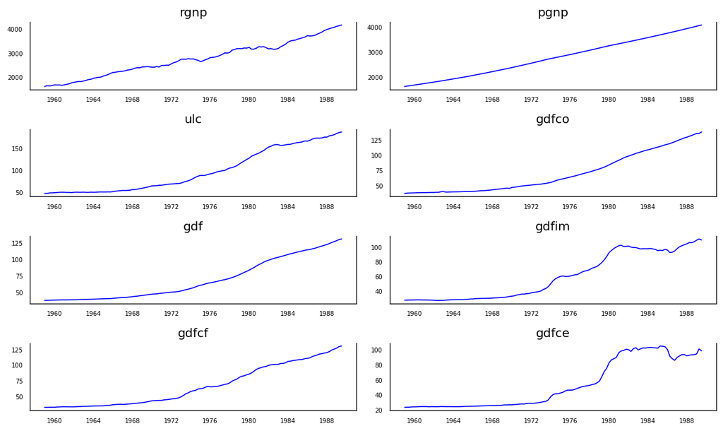

```python
#plot the images
fig, axes = plt.subplots(nrows=4,ncols=2, dpi=120,figsize=(10,6))

for i, ax in enumerate(axes.flatten()):
    data = df[df.columns[i]]
    ax.plot(data, color = 'blue', linewidth = 1)
    #decoration
    ax.set_title(df.columns[i])
    ax.xaxis.set_ticks_position('none')
    ax.yaxis.set_ticks_position('none')
    ax.spines['top'].set_alpha(0)
    ax.tick_params(labelsize=6)

plt.tight_layout();
```

So now what - let's work out if there is some causality there by using the Granger's test.

Granger can define the causality relationship based on two principles:

```
1: The cause happens prior to its effect.
2: The cause has unique information about the future values of its effect.
```

```python
import warnings
warnings.filterwarnings('ignore')

from statsmodels.tsa.stattools import grangercausalitytests
maxlag=12
test = 'ssr_chi2test'


def grangers_causation_matrix(data, variables, test='ssr_chi2test', verbose=False):
    """Check Granger Causality of all possible combinations of the Time series.
    The rows are the response variable, columns are predictors. The values in the table
    are the P-Values. P-Values lesser than the significance level (0.05), implies
    the Null Hypothesis that the coefficients of the corresponding past values is
    zero, that is, the X does not cause Y can be rejected.

    data      : pandas dataframe containing the time series variables
    variables : list containing names of the time series variables.
    """
    df = pd.DataFrame(np.zeros((len(variables), len(variables))), columns=variables, index=variables)
    for c in df.columns:
        for r in df.index:
            test_result = grangercausalitytests(data[[r, c]], maxlag=maxlag, verbose=False)
            p_values = [round(test_result[i+1][0][test][1],4) for i in range(maxlag)]
            if verbose: print(f'Y = {r}, X = {c}, P Values = {p_values}')
            min_p_value = np.min(p_values)
            df.loc[r, c] = min_p_value
    df.columns = [var + '_x' for var in variables]
    df.index = [var + '_y' for var in variables]
    return df

grangers_causation_matrix(df, variables = df.columns)
```

|  | rgnp_x | pgnp_x | ulc_x | gdfco_x | gdf_x | gdfim_x | gdfcf_x | gdfce_x |
| --- | --- | --- | --- | --- | --- | --- | --- | --- |
| rgnp_y | 1.0000 | 0.0003 | 0.0001 | 0.0212 | 0.0014 | 0.0620 | 0.0001 | 0.0071 |
| pgnp_y | 0.0000 | 1.0000 | 0.0000 | 0.0000 | 0.0000 | 0.0000 | 0.0000 | 0.0000 |
| ulc_y | 0.0000 | 0.0000 | 1.0000 | 0.0002 | 0.0000 | 0.0000 | 0.0000 | 0.0041 |
| gdfco_y | 0.0000 | 0.0000 | 0.0000 | 1.0000 | 0.0000 | 0.0000 | 0.0000 | 0.0000 |
| gdf_y | 0.0000 | 0.0000 | 0.0000 | 0.0000 | 1.0000 | 0.0000 | 0.0000 | 0.0000 |
| gdfim_y | 0.0011 | 0.0067 | 0.0014 | 0.0083 | 0.0011 | 1.0000 | 0.0004 | 0.0000 |
| gdfcf_y | 0.0000 | 0.0000 | 0.0008 | 0.0008 | 0.0000 | 0.0038 | 1.0000 | 0.0009 |
| gdfce_y | 0.0025 | 0.0485 | 0.0000 | 0.0002 | 0.0000 | 0.0000 | 0.0000 | 1.0000 |

Now we interpret the p-values in the following manner:

If a given p-value is < significance level (0.05), then, the corresponding X series (column) causes the Y (row).

For example, P-Value of 0.0001 at (row 1, column 3) represents the p-value of the Grangers Causality test ulc_x causing rgnp_y, which is less that the significance level of 0.05.

So, you can reject the null hypothesis and conclude ulc_x causes rgnp_y.

Looking at the P-Values in the above table, you can pretty much observe that all the variables (time series) in the system are interchangeably causing each other.

This makes this system of multi time series a good candidate for using VAR models to forecast.

##### Next Step

Cointegration test could help use to establish the presence of a statistically significant connection between two or more time series.

To do a Cointegration test we need to know what is ‘order of integration’ (d). An order of integration(d) is nothing but the number of differencing required to make a non-stationary time series stationary.

Now, as we have two or more time series, and there exists a linear combination of them that has an order of integration (d) less than that of the individual series, then the collection of series is said to be cointegrated.

When two or more time series are cointegrated, it means they have a long run, statistically significant relationship.

This is the basic premise on which Vector Autoregression(VAR) models is based on. So, it’s fairly common to implement the cointegration test before starting to build VAR models.

```python
from statsmodels.tsa.vector_ar.vecm import coint_johansen

def cointegration_test(df, alpha=0.05):
    """Perform Johanson's Cointegration Test and Report Summary"""
    out = coint_johansen(df,-1,5)
    d = {'0.90':0, '0.95':1, '0.99':2}
    traces = out.lr1
    cvts = out.cvt[:, d[str(1-alpha)]]
    def adjust(val, length= 6): return str(val).ljust(length)

    # Summary
    print('Name   ::  Test Stat > C(95%)    =>   Signif  \n', '--'*20)
    for col, trace, cvt in zip(df.columns, traces, cvts):
        print(adjust(col), ':: ', adjust(round(trace,2), 9), ">", adjust(cvt, 8), ' =>  ' , trace > cvt)

cointegration_test(df)
```

```
Name   ::  Test Stat > C(95%)    =>   Signif
 ----------------------------------------
rgnp   ::  248.0     > 143.6691  =>   True
pgnp   ::  183.12    > 111.7797  =>   True
ulc    ::  130.01    > 83.9383   =>   True
gdfco  ::  85.28     > 60.0627   =>   True
gdf    ::  55.05     > 40.1749   =>   True
gdfim  ::  31.59     > 24.2761   =>   True
gdfcf  ::  14.06     > 12.3212   =>   True
gdfce  ::  0.45      > 4.1296    =>   False
```

##### Next Step

We split the Series into Training and Testing Data.

```python
nobs = 4
df_train, df_test = df[0:-nobs], df[-nobs:]

# Check size
print(df_train.shape)  # (119, 8)
print(df_test.shape)  # (4, 8)
```

```
(119, 8)
(4, 8)
```

#### Next Step

We want to check for Stationarity and Make the Time Series Stationary

As the VAR model requires the time series you want to forecast to be stationary, it is customary to check all the time series in the system for stationarity.

A stationary time series is one whose characteristics like mean and variance does not change over time.

So, how to test for stationarity?

There is a suite of tests called unit-root tests. The popular ones are:

Augmented Dickey-Fuller Test (ADF Test) KPSS test Philip-Perron test Let’s use the ADF test for our purpose.

By the way, if a series is found to be non-stationary, you make it stationary by differencing the series once and repeat the test again until it becomes stationary.

Since, differencing reduces the length of the series by 1 and since all the time series has to be of the same length, you need to difference all the series in the system if you choose to difference at all.

Let’s implement the ADF Test.

First, we implement a nice function (adfuller_test()) that writes out the results of the ADF test for any given time series and implement this function on each series one-by-one

```python
def adfuller_test(series, signif=0.05, name='', verbose=False):
    """Perform ADFuller to test for Stationarity of given series and print report"""
    r = adfuller(series, autolag='AIC')
    output = {'test_statistic':round(r[0], 4), 'pvalue':round(r[1], 4), 'n_lags':round(r[2], 4), 'n_obs':r[3]}
    p_value = output['pvalue']
    def adjust(val, length= 6): return str(val).ljust(length)

    # Print Summary
    print(f'    Augmented Dickey-Fuller Test on "{name}"', "\n   ", '-'*47)
    print(f' Null Hypothesis: Data has unit root. Non-Stationary.')
    print(f' Significance Level    = {signif}')
    print(f' Test Statistic        = {output["test_statistic"]}')
    print(f' No. Lags Chosen       = {output["n_lags"]}')

    for key,val in r[4].items():
        print(f' Critical value {adjust(key)} = {round(val, 3)}')

    if p_value <= signif:
        print(f" => P-Value = {p_value}. Rejecting Null Hypothesis.")
        print(f" => Series is Stationary.")
    else:
        print(f" => P-Value = {p_value}. Weak evidence to reject the Null Hypothesis.")
        print(f" => Series is Non-Stationary.")
```

```python
# ADF Test on each column
for name, column in df_train.items():
    adfuller_test(column, name=column.name)
    print('\n')
```

```
    Augmented Dickey-Fuller Test on "rgnp"
    -----------------------------------------------
 Null Hypothesis: Data has unit root. Non-Stationary.
 Significance Level    = 0.05
 Test Statistic        = 0.5428
 No. Lags Chosen       = 2
 Critical value 1%     = -3.488
 Critical value 5%     = -2.887
 Critical value 10%    = -2.58
 => P-Value = 0.9861. Weak evidence to reject the Null Hypothesis.
 => Series is Non-Stationary.


    Augmented Dickey-Fuller Test on "pgnp"
    -----------------------------------------------
 Null Hypothesis: Data has unit root. Non-Stationary.
 Significance Level    = 0.05
 Test Statistic        = 1.1556
 No. Lags Chosen       = 1
 Critical value 1%     = -3.488
 Critical value 5%     = -2.887
 Critical value 10%    = -2.58
 => P-Value = 0.9957. Weak evidence to reject the Null Hypothesis.
 => Series is Non-Stationary.


    Augmented Dickey-Fuller Test on "ulc"
    -----------------------------------------------
 Null Hypothesis: Data has unit root. Non-Stationary.
 Significance Level    = 0.05
 Test Statistic        = 1.2474
 No. Lags Chosen       = 2
 Critical value 1%     = -3.488
 Critical value 5%     = -2.887
 Critical value 10%    = -2.58
 => P-Value = 0.9963. Weak evidence to reject the Null Hypothesis.
 => Series is Non-Stationary.


    Augmented Dickey-Fuller Test on "gdfco"
```

[output cut: 47 more lines]

```
 => P-Value = 0.9973. Weak evidence to reject the Null Hypothesis.
 => Series is Non-Stationary.


    Augmented Dickey-Fuller Test on "gdfce"
    -----------------------------------------------
 Null Hypothesis: Data has unit root. Non-Stationary.
 Significance Level    = 0.05
 Test Statistic        = -0.3402
 No. Lags Chosen       = 8
 Critical value 1%     = -3.491
 Critical value 5%     = -2.888
 Critical value 10%    = -2.581
 => P-Value = 0.9196. Weak evidence to reject the Null Hypothesis.
 => Series is Non-Stationary.
```

The ADF test confirms none of the time series is stationary. Let’s difference all of them once and check again.

```python
# 1st difference
df_differenced = df_train.diff().dropna()

# ADF Test on each column of 1st Differences Dataframe
for name, column in df_differenced.items():
    adfuller_test(column, name=column.name)
    print('\n')
```

```
    Augmented Dickey-Fuller Test on "rgnp"
    -----------------------------------------------
 Null Hypothesis: Data has unit root. Non-Stationary.
 Significance Level    = 0.05
 Test Statistic        = -5.3448
 No. Lags Chosen       = 1
 Critical value 1%     = -3.488
 Critical value 5%     = -2.887
 Critical value 10%    = -2.58
 => P-Value = 0.0. Rejecting Null Hypothesis.
 => Series is Stationary.


    Augmented Dickey-Fuller Test on "pgnp"
    -----------------------------------------------
 Null Hypothesis: Data has unit root. Non-Stationary.
 Significance Level    = 0.05
 Test Statistic        = -1.8282
 No. Lags Chosen       = 0
 Critical value 1%     = -3.488
 Critical value 5%     = -2.887
 Critical value 10%    = -2.58
 => P-Value = 0.3666. Weak evidence to reject the Null Hypothesis.
 => Series is Non-Stationary.


    Augmented Dickey-Fuller Test on "ulc"
    -----------------------------------------------
 Null Hypothesis: Data has unit root. Non-Stationary.
 Significance Level    = 0.05
 Test Statistic        = -3.4658
 No. Lags Chosen       = 1
 Critical value 1%     = -3.488
 Critical value 5%     = -2.887
 Critical value 10%    = -2.58
 => P-Value = 0.0089. Rejecting Null Hypothesis.
 => Series is Stationary.


    Augmented Dickey-Fuller Test on "gdfco"
```

[output cut: 47 more lines]

```
 => P-Value = 0.2632. Weak evidence to reject the Null Hypothesis.
 => Series is Non-Stationary.


    Augmented Dickey-Fuller Test on "gdfce"
    -----------------------------------------------
 Null Hypothesis: Data has unit root. Non-Stationary.
 Significance Level    = 0.05
 Test Statistic        = -3.1543
 No. Lags Chosen       = 7
 Critical value 1%     = -3.491
 Critical value 5%     = -2.888
 Critical value 10%    = -2.581
 => P-Value = 0.0228. Rejecting Null Hypothesis.
 => Series is Stationary.
```

All of the series in the VAR model should have the same number of observations.

So, we are left with one of two choices.

That is, either proceed with 1st differenced series or difference all the series one more time.

```python
# Second Differencing
df_differenced = df_differenced.diff().dropna()

# ADF Test on each column of 2nd Differences Dataframe
for name, column in df_differenced.items():
    adfuller_test(column, name=column.name)
    print('\n')
```

```
    Augmented Dickey-Fuller Test on "rgnp"
    -----------------------------------------------
 Null Hypothesis: Data has unit root. Non-Stationary.
 Significance Level    = 0.05
 Test Statistic        = -9.0123
 No. Lags Chosen       = 2
 Critical value 1%     = -3.489
 Critical value 5%     = -2.887
 Critical value 10%    = -2.58
 => P-Value = 0.0. Rejecting Null Hypothesis.
 => Series is Stationary.


    Augmented Dickey-Fuller Test on "pgnp"
    -----------------------------------------------
 Null Hypothesis: Data has unit root. Non-Stationary.
 Significance Level    = 0.05
 Test Statistic        = -10.9813
 No. Lags Chosen       = 0
 Critical value 1%     = -3.488
 Critical value 5%     = -2.887
 Critical value 10%    = -2.58
 => P-Value = 0.0. Rejecting Null Hypothesis.
 => Series is Stationary.


    Augmented Dickey-Fuller Test on "ulc"
    -----------------------------------------------
 Null Hypothesis: Data has unit root. Non-Stationary.
 Significance Level    = 0.05
 Test Statistic        = -8.769
 No. Lags Chosen       = 2
 Critical value 1%     = -3.489
 Critical value 5%     = -2.887
 Critical value 10%    = -2.58
 => P-Value = 0.0. Rejecting Null Hypothesis.
 => Series is Stationary.


    Augmented Dickey-Fuller Test on "gdfco"
```

[output cut: 47 more lines]

```
 => P-Value = 0.0. Rejecting Null Hypothesis.
 => Series is Stationary.


    Augmented Dickey-Fuller Test on "gdfce"
    -----------------------------------------------
 Null Hypothesis: Data has unit root. Non-Stationary.
 Significance Level    = 0.05
 Test Statistic        = -5.1732
 No. Lags Chosen       = 8
 Critical value 1%     = -3.492
 Critical value 5%     = -2.889
 Critical value 10%    = -2.581
 => P-Value = 0.0. Rejecting Null Hypothesis.
 => Series is Stationary.
```

All the series are now stationary.

Let’s prepare the training and test datasets.

How to Select the Order (P) of VAR model To select the right order of the VAR model, we iteratively fit increasing orders of VAR model and pick the order that gives a model with least AIC. The Akaike Information Criterion (AIC) lets you test how well your model fits the data set without over-fitting it.

Though the usual practice is to look at the AIC, you can also check other best fit comparison estimates of BIC, FPE and HQIC.

```python
model = VAR(df_differenced)
for i in [1,2,3,4,5,6,7,8,9]:
    result = model.fit(i)
    print('Lag Order =', i)
    print('AIC : ', result.aic)
    print('BIC : ', result.bic)
    print('FPE : ', result.fpe)
    print('HQIC: ', result.hqic, '\n')
```

```
Lag Order = 1
AIC :  -1.36794023154507
BIC :  0.34118471465888023
FPE :  0.25526825173471884
HQIC:  -0.674133133569959

Lag Order = 2
AIC :  -1.6212373944478267
BIC :  1.6249432095295822
FPE :  0.20113494371371338
HQIC:  -0.303628882679595

Lag Order = 3
AIC :  -1.7658008387012818
BIC :  3.0345473163767807
FPE :  0.18125103746164314
HQIC:  0.1823914378396303

Lag Order = 4
AIC :  -2.000735164470316
BIC :  4.371215137654089
FPE :  0.15556966521481125
HQIC:  0.5849359332771087

Lag Order = 5
AIC :  -1.9619535608363963
BIC :  5.999364562242095
FPE :  0.1869279438911487
HQIC:  1.268206331178332

Lag Order = 6
AIC :  -2.3303386524829035
BIC :  7.238452689088582
FPE :  0.16380374017443694
HQIC:  1.551437166954809

Lag Order = 7
AIC :  -2.592331352347127
BIC :  8.602387254937797
FPE :  0.18238685837154173
HQIC:  1.948306962114657

Lag Order = 8
AIC :  -3.317261976458205
BIC :  9.52219581032303
FPE :  0.15573163248209088
HQIC:  1.8896071386220985

Lag Order = 9
AIC :  -4.804763125958628
BIC :  9.6986131392316
FPE :  0.08421466682671945
HQIC:  1.0758291640834088
```

Let’s go with the lag 4 model. An alternate method to choose the order(p) of the VAR models is to use the model.select_order(maxlags) method.

The selected order(p) is the order that gives the lowest ‘AIC’, ‘BIC’, ‘FPE’ and ‘HQIC’ scores.

```python
x = model.select_order(maxlags=10)
x.summary()
```

VAR Order Selection (* highlights the minimums)

|  | AIC | BIC | FPE | HQIC |
| --- | --- | --- | --- | --- |
| 0 | -0.2124 | -0.01258* | 0.8086 | -0.1314* |
| 1 | -0.7258 | 1.073 | 0.4855 | 0.003288 |
| 2 | -0.9924 | 2.405 | 0.3788 | 0.3848 |
| 3 | -1.195 | 3.801 | 0.3248 | 0.8304 |
| 4 | -1.451 | 5.144 | 0.2768 | 1.223 |
| 5 | -1.443 | 6.751 | 0.3285 | 1.879 |
| 6 | -1.939 | 7.853 | 0.2590 | 2.030 |
| 7 | -2.339 | 9.051 | 0.2567 | 2.278 |
| 8 | -3.185 | 9.805 | 0.1968 | 2.081 |
| 9 | -4.822 | 9.767 | 0.09029 | 1.092 |
| 10 | -6.671* | 9.516 | 0.05201* | -0.1090 |

I, however, don’t have an explanation for why the observed AIC and BIC values differ when using result.aic versus as seen using model.select_order().

```python
model_fitted = model.fit(4)
model_fitted.summary()
```

```
  Summary of Regression Results
==================================
Model:                         VAR
Method:                        OLS
Date:           Fri, 24, May, 2024
Time:                     23:25:20
--------------------------------------------------------------------
No. of Equations:         8.00000    BIC:                    4.37122
Nobs:                     113.000    HQIC:                  0.584936
Log likelihood:          -905.679    FPE:                   0.155570
AIC:                     -2.00074    Det(Omega_mle):       0.0200322
--------------------------------------------------------------------
Results for equation rgnp
===========================================================================
              coefficient       std. error           t-stat            prob
---------------------------------------------------------------------------
const            2.430021         2.677505            0.908           0.364
L1.rgnp         -0.750066         0.159023           -4.717           0.000
L1.pgnp         -0.095621         4.938865           -0.019           0.985
L1.ulc          -6.213996         4.637452           -1.340           0.180
L1.gdfco        -7.414768        10.184884           -0.728           0.467
L1.gdf         -24.864063        20.071245           -1.239           0.215
L1.gdfim         1.082913         4.309034            0.251           0.802
L1.gdfcf        16.327252         5.892522            2.771           0.006
L1.gdfce         0.910522         2.476361            0.368           0.713
L2.rgnp         -0.568178         0.163971           -3.465           0.001
L2.pgnp         -1.156201         4.931931           -0.234           0.815
L2.ulc         -11.157111         5.381825           -2.073           0.038
L2.gdfco         3.012518        12.928317            0.233           0.816
L2.gdf         -18.143523        24.090598           -0.753           0.451
L2.gdfim        -4.438115         4.410654           -1.006           0.314
L2.gdfcf        13.468228         7.279772            1.850           0.064
L2.gdfce         5.130419         2.805310            1.829           0.067
L3.rgnp         -0.514985         0.152724           -3.372           0.001
L3.pgnp        -11.483607         5.392037           -2.130           0.033
L3.ulc         -14.195308         5.188718           -2.736           0.006
L3.gdfco       -10.154967        13.105508           -0.775           0.438
L3.gdf         -15.438858        21.610822           -0.714           0.475
L3.gdfim        -6.405290         4.292790           -1.492           0.136
L3.gdfcf         9.217402         7.081652            1.302           0.193
```

[output cut: 279 more lines]

```
L4.gdfim         0.076950         0.236816            0.325           0.745
L4.gdfcf        -0.045155         0.343384           -0.132           0.895
L4.gdfce        -0.473155         0.152468           -3.103           0.002
===========================================================================

Correlation matrix of residuals
             rgnp      pgnp       ulc     gdfco       gdf     gdfim     gdfcf     gdfce
rgnp     1.000000  0.248342 -0.668492 -0.160133 -0.047777  0.084925  0.009962  0.205557
pgnp     0.248342  1.000000 -0.148392 -0.167766 -0.134896  0.007830 -0.169435  0.032134
ulc     -0.668492 -0.148392  1.000000  0.268127  0.327761  0.171497  0.135410 -0.026037
gdfco   -0.160133 -0.167766  0.268127  1.000000  0.303563  0.232997 -0.035042  0.184834
gdf     -0.047777 -0.134896  0.327761  0.303563  1.000000  0.196670  0.446012  0.309277
gdfim    0.084925  0.007830  0.171497  0.232997  0.196670  1.000000 -0.089852  0.707809
gdfcf    0.009962 -0.169435  0.135410 -0.035042  0.446012 -0.089852  1.000000 -0.197099
gdfce    0.205557  0.032134 -0.026037  0.184834  0.309277  0.707809 -0.197099  1.000000
```

#### Next Section Some Visuals on Natural Gas

```python
# communication with open data repository
import requests

# data wrangler (pre-processing)
import pandas as pd

# plot figures
import matplotlib.pyplot as plt
from  matplotlib.ticker import FuncFormatter
import seaborn as sns
sns.set_theme(style="dark")

# helper libs
from IPython.display import display, Markdown
import datetime
import calendar
import json

import warnings
warnings.filterwarnings("ignore")
```

```python
    %matplotlib inline

# %%javascript # needed to prevent the vertical scrollbar to appear
# IPython.OutputArea.prototype._should_scroll = function(lines) { return false; }
```

```python
# read index from the CBS server
odata_index = json.loads(
    requests.get(
        "https://opendata.cbs.nl/ODataApi/odata/00372eng", verify=False
    ).text
)
```

```python
# read data files
data = {}
for data_file in odata_index["value"]:
    data[data_file["name"]] = json.loads(
        requests.get(data_file["url"], verify=False).text
    )

# keep only the required information...
summary = data["TableInfos"]
description = data["DataProperties"]["value"]
df = data["TypedDataSet"]["value"]

# ... and delete the rest
del data
```

```python
# load data into a dataframe
description = pd.DataFrame(description)
df = pd.DataFrame(df)

# turn the description into a data dictionary
description = description[description["Key"] != ""]
data_dictionary = description.set_index("Key")
data_dictionary = data_dictionary[
    [
        "Title",
        "Description",
        "Unit",
    ]
].to_dict("index")
```

```python
df = df.fillna(0)  # replace null with zeros

# keep only the monthly records
df = df[df["Periods"].str.contains("MM")]
```

```python
# create year, month, day column, and generate a date column
df["Year"] = df["Periods"].apply(lambda x: int(x[0:4]))
df["Month"] = df["Periods"].apply(lambda x: int(x[6:9]))
df["Day"] = 1
df["Date"] = pd.to_datetime(df[["Year", "Month", "Day"]])

# keep a human friendly label for our months
df["MonthLabel"] = df["Month"].apply(lambda x: calendar.month_abbr[x])

# and remove the column "Periods"
df = df.drop(["Periods"], axis = 1)

# optimize the information in the DataFrame
df['Year'] = df['Year'].astype('int16')
df['Month'] = df['Month'].astype('int16')
df['Day'] = df['Day'].astype('int16')
```

```python
df["import"] = (  # create totals for import
    df["ImportsOfGaseousNaturalGasTotal_4"] + \
        df["ImportsOfLiquefiedNaturalGasLng_10"]
)

df["export"] = (  # create totals for export
    df["ExportsOfGaseousNaturalGasTotal_11"] + \
        df["ExportsOfLiquefiedNaturalGasLng_17"]
)

# product total
df["production"] = df["IndigenousProduction_2"] + \
    df["ProductionFromOtherSources_3"]

# total consumption (better label)
df["consumption"] = df["TotalConsumption_20"]

# in/out
df["in"] = df["import"] + df["production"]
df["out"] = df["export"] + df["consumption"]
```

```python
# last x years
current_year = int(datetime.datetime.now().date().strftime("%Y"))
df = df[df['Year'] >= current_year - 20] # last 20 years
```

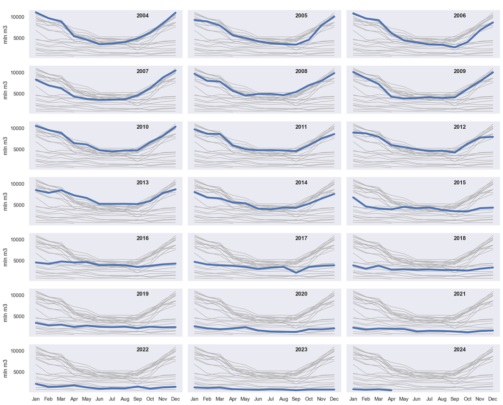

```python
# Natural gas production in the Netherlands

# from the data dictionary retrieve the unit for this column
from matplotlib.pyplot import grid

gas_volume_units = data_dictionary["IndigenousProduction_2"]["Unit"]

# Natural gas production by year (blue line)
g = sns.relplot(
    data=df,
    x="MonthLabel",
    y="IndigenousProduction_2",
    col="Year",
    kind="line",
    linewidth=4,
    zorder=5,
    col_wrap=3,
    height=3,
    aspect=2,
    legend=True,
)

# Iterate over each subplot to customize further (grey line)
for year, ax in g.axes_dict.items():
    ax.text(0.7, 0.85, year, transform=ax.transAxes, fontweight="bold")
    sns.lineplot(
        data=df,
        x="MonthLabel",
        y="IndigenousProduction_2",
        units="Year",
        estimator=None,
        color=".7",
        linewidth=1,
        ax=ax,
    )

# layout
g.set_titles(" ")
g.set_axis_labels("", gas_volume_units)
plt.gcf().set_size_inches(15, 12)
plt.show()
```

```python
production_consumption_df = pd.melt(  # set data
    df, id_vars=["Year"], value_vars=["production", "consumption"]
)
production_consumption_df.head(10)
```

|  | Year | variable | value |
| --- | --- | --- | --- |
| 0 | 2004 | production | 11088.0 |
| 1 | 2004 | production | 9693.0 |
| 2 | 2004 | production | 8896.0 |
| 3 | 2004 | production | 5424.0 |
| 4 | 2004 | production | 4586.0 |
| 5 | 2004 | production | 3522.0 |
| 6 | 2004 | production | 3664.0 |
| 7 | 2004 | production | 4031.0 |
| 8 | 2004 | production | 4876.0 |
| 9 | 2004 | production | 6258.0 |

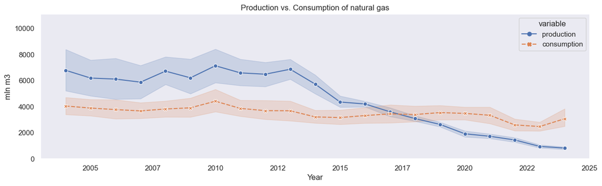

```python
##############################################################################
# production / consumption

sns.lineplot(  # plot
    x="Year",
    y="value",
    hue="variable",
    style="variable",
    markers=True,
    data=production_consumption_df,
).xaxis.set_major_formatter( # force year labels to integers
    FuncFormatter(lambda x, _: int(x))
)

# layout
plt.ylim(0, production_consumption_df["value"].max())
plt.ylabel(gas_volume_units)
plt.title("Production vs. Consumption of natural gas")
plt.gcf().set_size_inches(15, 4)
plt.show()
```

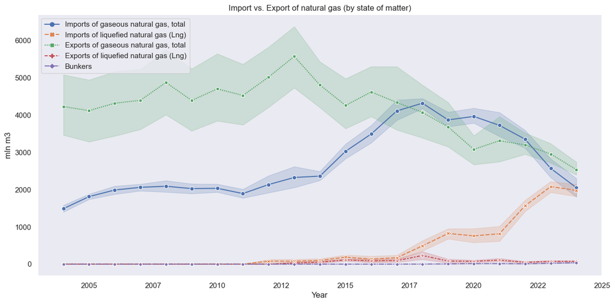

**Imports of gaseous natural gas, total:** Imports of gaseous natural gas through cross border pipelines.

**Imports of liquefied natural gas (Lng):** Imports of liquefied natural gas (Lng). The gas is liquefied through cooling till about minus 160 degrees Celsius. This makes transport in ships over long distances possible.

**Exports of gaseous natural gas, total:** Exports of gaseous natural gas through cross border pipelines.

**Exports of liquefied natural gas (Lng):** Exports of liquefied natural gas (Lng). The gas is liquefied through cooling till about minus 160 degrees Celsius. This makes transport in ships over long distances possible.

**Bunkers:** Delivery of fuels for international shipping and aviation, i.e. ships and aircraft departing from Dutch (air)ports and arriving in foreign (air)ports. Bunkers are considered as a form of export and are not included in energy available for consumption in the Netherlands.

```python
##############################################################################
# import vs export by state

import_export_state_df = pd.melt(  # set data
    df,
    id_vars=["Year"],
    value_vars=[
        "ImportsOfGaseousNaturalGasTotal_4",
        "ImportsOfLiquefiedNaturalGasLng_10",
        "ExportsOfGaseousNaturalGasTotal_11",
        "ExportsOfLiquefiedNaturalGasLng_17",
        "Bunkers_18"
    ],
)

# Gas import/export
ie = sns.lineplot(  # plot
    x="Year",
    y="value",
    hue="variable",
    style="variable",
    markers=True,
    data=import_export_state_df,
)

ie.xaxis.set_major_formatter( # force year labels to integers
    FuncFormatter(lambda x, _: int(x))
)

# labels
handles, labels = ie.get_legend_handles_labels()
ie.legend(
    handles,
    [data_dictionary[l]["Title"] for l in labels],
    loc="upper left"
)

# layout
plt.ylabel(gas_volume_units)
plt.title("Import vs. Export of natural gas (by state of matter)")
plt.gcf().set_size_inches(15, 7)
plt.show()

for l in labels:
    display(Markdown(f"**{data_dictionary[l]['Title']}:** {data_dictionary[l]['Description']}"))
```